# DA HW4 박정명 제출

2022-11-25

# Preparing data1 dataset

```r
dataset <- NHANES %>%
  mutate(male = ifelse(Gender == "male", 1, 0),
         age = Age,
         white = ifelse(Race1 == "White", 1, 0),
         black = ifelse(Race1 == "Black", 1, 0),
         hs= recode(Education, "8th Grade" = 0,
                    "9 - 11th Grade" = 0,
                    "High School" = 1,
                    "Some College" = 1,
                    "College Grad" = 1),
         income_high = ifelse(HHIncome %in% c("75000-99999", "more 99999"), 1, 0),
         income_low = ifelse(HHIncome %in% c(" 0-4999", " 5000-9999", "10000-14999", "15000-19999", "20000-24999"), 1, 0),
         BMI = BMI,
         own = recode(HomeOwn, "Own"=1,
                      "Rent"=0, "Other"=0),
         phy_act_yes = ifelse(PhysActive == "Yes", 1, 0))

data1 <- dataset %>% dplyr::select(male, Age, white, black, hs, income_high, income_low, BMI, own, phy_act_yes)
data1 <- data1[complete.cases(data1),]
```

### Seperating to training and test sets.

```r
data1 = data1 %>%
mutate(phy = as.factor(phy_act_yes))
set.seed(1111)
n <- nrow(data1)
nhanes_parts <- data1 %>%
initial_split(prop = 0.8)
train <- nhanes_parts %>%
training()
test <- nhanes_parts %>%
testing()
```

# Question 1)

## Question 1a)

Report the sizes of the training and testing sets, that is, ntrain, ntest.

```r
c(train=nrow(train),test =nrow(test)) %>% data.frame() %>%
  rename("count"= ".") %>%
  mutate(prop= count/sum(count))
```

```
##       count      prop
## train  5688 0.7998875
## test   1423 0.2001125
```

As we wanted,we have a 80:20 split

## Question 1b)

Suppose we fit a simple model phy_act_yes ~ bmi (say, Model 1) using the training set. Show the confusion matrix.

```r
model1= glm(phy~BMI, data= train, family="binomial")
pred1= ifelse(model1$fitted.values>0.5, 1,0)
table_lr= table(pred1, real=train$phy)
table_lr
```

```
##      real
## pred1    0    1
##     0 1003  734
##     1 1691 2260
```

## Question 1c)

```r
accuracy = function(table){(table[1,1]+table[2,2])/sum(table)}
accuracy(table_lr)
```

```
## [1] 0.5736639
```

```r
sensitivity = function(table){(table[2,2])/(table[2,1]+table[1,2])}
sensitivity(table_lr)
```

```
## [1] 0.9319588
```

```r
specificity = function(table){(table[1,1])/(table[1,1]+table[2,1])}
specificity(table_lr)
```

```
## [1] 0.3723088
```

```r
precision = function(table){(table[2,2])/(table[2,1]+table[2,2])}
precision(table_lr)
```

```
## [1] 0.5720071
```

Accuracy is 0.5736639 meaning that 57.4% of predictions are correct.

Specificity is 0.3723088 meaning that out of the people who are actually physically inactive, 37.2% of the people actually got predicted as physically inactive.

Precision is 0.5720071 meaning when the model predicts someone to be physically active, the model correctly predicts 57.2% of the time.

## Question 1d)

```r
model_1d2= logistic_reg(mode = "classification") %>%
  set_engine("glm") %>%
  fit(phy~BMI+male+Age, data = train)

model_1d3= logistic_reg(mode = "classification") %>%
  set_engine("glm") %>%
  fit(phy ~ BMI + male + Age+white+ black, data = train)

model_1d4= logistic_reg(mode = "classification") %>%
  set_engine("glm") %>%
  fit(phy ~ BMI + male + Age + white + black + income_high + income_low, data = train)


model_1d5= logistic_reg(mode = "classification") %>%
  set_engine("glm") %>%
  fit(phy ~ BMI + male + Age + white + black + income_high + income_low + hs + own, data = train)
```

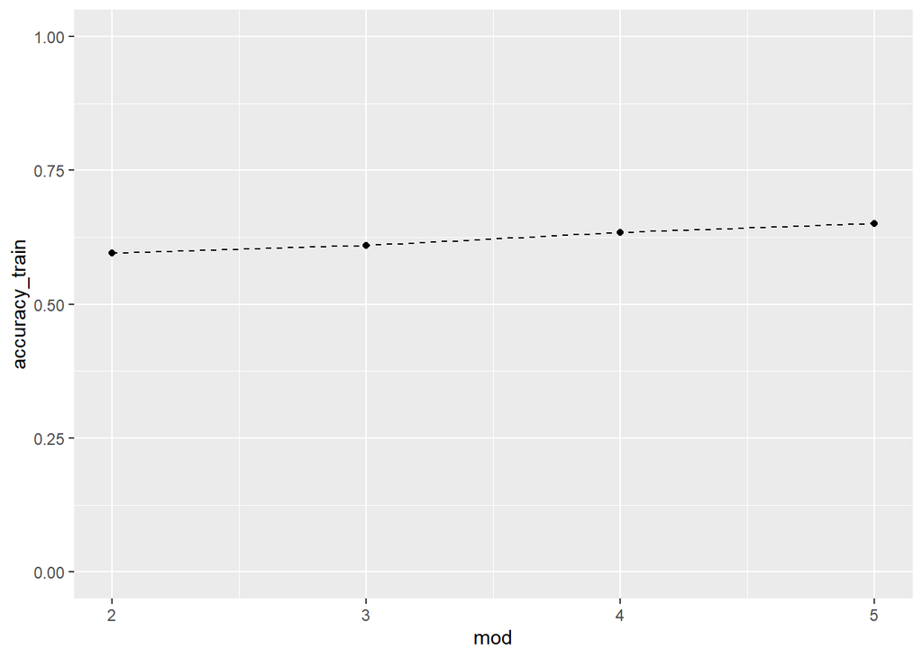

```r
mods <- tibble(
  type = c("model_1d2", "model_1d3", "model_1d4", "model_1d5"),
  mod = list(model_1d2, model_1d3, model_1d4, model_1d5)
)

mods <- mods %>%
  mutate(
    y_train = list(pull(train, phy)),
    y_test = list(pull(test, phy)),
    y_hat_train = map(
      mod,
      ~pull(predict(.x, new_data = train, type = "class"), .pred_class)
    ),
    y_hat_test = map(
      mod,
      ~pull(predict(.x, new_data = test, type = "class"), .pred_class)
    ),
    accuracy_train = map2_dbl(y_train, y_hat_train, accuracy_vec)
  )
mods %>%  dplyr::select(accuracy_train) %>%  mutate(mod= 2:5) %>%
  ggplot(aes(mod, accuracy_train))+
  geom_point()+
  geom_line(linetype="dashed")+
  ylim(0,1)
```

Model_1d5 has the highest accuracy. In fact, as we increase the number of predictor variables, the accuracy increases. This is expected as more variables can explain the variability in phy_act_yes.This may or may not create a problem of overfitting, depending on how many more additional variables are added. We will see in question 1e) if this is the case or not using the test set.

## Question 1e)

```r
mods <- mods %>%
  mutate(
    accuracy_test = map2_dbl(y_test, y_hat_test, accuracy_vec),
    sens_test =
      map2_dbl(y_test, y_hat_test, sens_vec, event_level = "second"),
    spec_test =
      map2_dbl(y_test, y_hat_test, spec_vec, event_level = "second")
  )

mods %>% dplyr::select(accuracy_train, accuracy_test, sens_test, spec_test)
```

```
## # A tibble: 4 × 4
##   accuracy_train accuracy_test sens_test spec_test
##            <dbl>         <dbl>     <dbl>     <dbl>
## 1          0.596         0.573     0.684     0.451
## 2          0.609         0.592     0.686     0.487
## 3          0.634         0.623     0.686     0.554
## 4          0.651         0.625     0.712     0.529
```

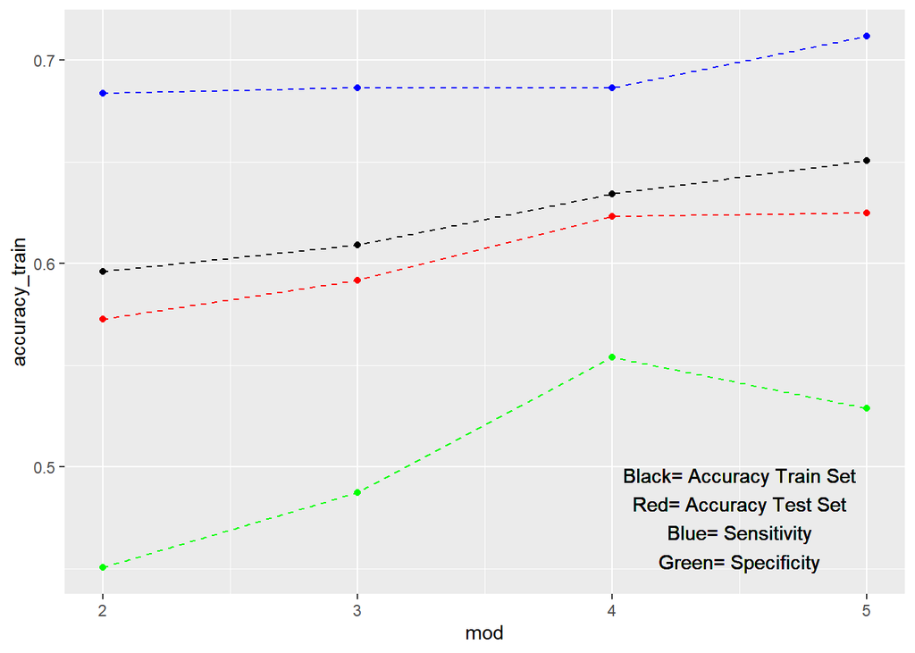

```r
mods %>% dplyr::select(accuracy_train,accuracy_test, sens_test, spec_test) %>%  mutate(mod= 2:5) %>%
  ggplot()+
  geom_point(aes(mod, accuracy_train))+
  geom_line(aes(mod, accuracy_train), linetype="dashed")+
  geom_point(aes(mod, accuracy_test), color="red")+
  geom_line(aes(mod, accuracy_test), color= "red", linetype="dashed")+
  geom_point(aes(mod, sens_test), color= "blue")+
  geom_line(aes(mod, sens_test),color= "blue", linetype= "dashed")+
  geom_point(aes(mod, spec_test), color= "green")+
  geom_line(aes(mod, spec_test), color= "green", linetype= "dashed")+
  geom_text(x= 4.5, y= 0.475, label = "Black= Accuracy Train Set\nRed= Accuracy Test Set\nBlue= Sensitivity\nGreen= Specificity")
```

Each model performed slightly worse on the testing set than it did on the training set for accuracy.

## Question 1e)

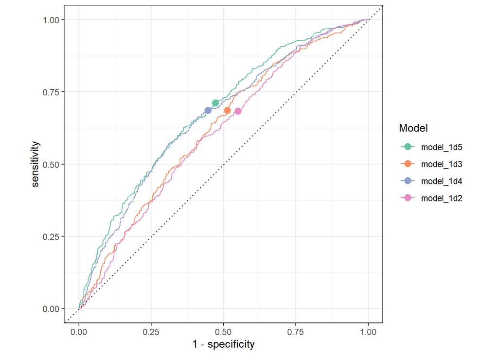

```r
mods <- mods %>%
  mutate(
    y_hat_prob_test = map(
      mod,
      ~pull(predict(.x, new_data = test, type = "prob"))
    ),
    type = fct_reorder(type, sens_test, .desc = TRUE)
  )
mods %>%
  dplyr::select(type, y_test, y_hat_prob_test) %>%
  unnest(cols = c(y_test, y_hat_prob_test)) %>%
  group_by(type) %>%
  roc_curve(truth = y_test, y_hat_prob_test, event_level = "second") %>%
  autoplot() +
  geom_point(
    data = mods,
    aes(x = 1 - spec_test, y = sens_test, color = type),
    size = 3
  ) +
  scale_color_brewer("Model", palette = "Set2")
```

Model_1d5 has the largest AUC as we can see that this model’s ROC curve is closest to the top left corner.

The dot on each ROC curve is the value of sensitivity and 1-specificity when our threshold is 0.5. (The values we saw in the answer of question 1e)

# Question 2)

## Question 2a)

```r
BMI_model <- formula(
"BMI ~ male + Age + white + black + hs + income_high + income_low + own + phy_act_yes"
)
```

```r
penalty= c(0.01, 0.05, 0.1, 0.25, 0.3, 0.5, 1, 2)
for (i in penalty){
mod_lasso <- linear_reg(penalty = i, mixture = 1) %>%
  set_engine("glmnet") %>%
  fit(BMI_model, data = train)
print(tidy(mod_lasso))
}
```

```
## # A tibble: 10 × 3
##    term        estimate penalty
##    <chr>          <dbl>   <dbl>
##  1 (Intercept) 28.8        0.01
##  2 male         0.0804     0.01
##  3 Age          0.00790    0.01
##  4 white        0.215      0.01
##  5 black        2.26       0.01
##  6 hs           0.164      0.01
##  7 income_high -0.460      0.01
##  8 income_low   0.514      0.01
##  9 own          0.152      0.01
## 10 phy_act_yes -1.80       0.01
## # A tibble: 10 × 3
##    term        estimate penalty
```

[output cut: 89 more lines]

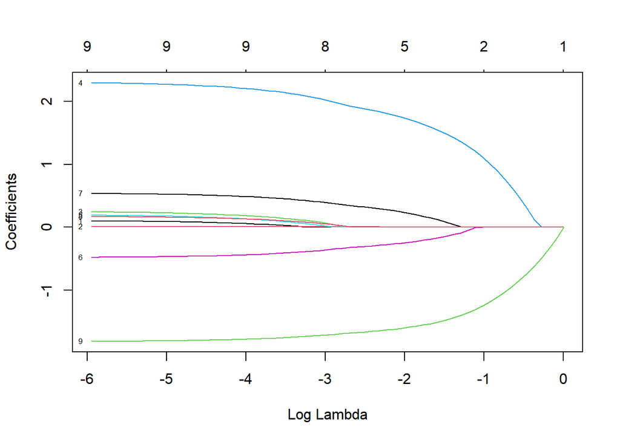

```r
plot(mod_lasso$fit, xvar="lambda", label=TRUE)
```

I choose black and phy_act_yes as we can see from the LASSO variable trace plots that coefficient 9(phy_act_yes) and coefficient 4(black) colored lines are the lines that tend to 0 the slowest(i.e even at a high penalty, they are still present while the other coefficients become 0 as they weren’t influential enough). We can also see this from the results of the for loop where at a penalty of 0.5, phy_act_yes and black coefficients are the only ones that are non-zero.

## Question 2b)

After, I would choose black, income_high, income_low, phy_act_yes as the four predictor variables since at a penalty of 0.25, their coefficients are the ones that are non-zero. Same can be seen in the LASSO variable trace plot where coefficient 6(income_high) and coefficient 6(income_low) tend to 0 the next slowest

## Question 2c)

```r
BMI_model_a= formula(
"BMI ~ black + phy_act_yes"
)
BMI_model_b= formula(
"BMI ~ black +income_high+ income_low + phy_act_yes"
)

mod_lasso_a <- linear_reg(penalty = 0.5, mixture = 1) %>%
  set_engine("glmnet") %>%
  fit(BMI_model_a, data = test)

test %>%
  dplyr::select(BMI) %>%
  bind_cols(predict(mod_lasso_a, new_data = test)) %>%
  metrics(truth = BMI, estimate = .pred)
```

```
## # A tibble: 3 × 3
##   .metric .estimator .estimate
##   <chr>   <chr>          <dbl>
## 1 rmse    standard      6.32
## 2 rsq     standard      0.0274
## 3 mae     standard      4.73
```

```r
mod_lasso_b <- linear_reg(penalty = 0.5, mixture = 1) %>%
  set_engine("glmnet") %>%
  fit(BMI_model_b, data = test)

test %>%
  dplyr::select(BMI) %>%
  bind_cols(predict(mod_lasso_b, new_data = test)) %>%
  metrics(truth = BMI, estimate = .pred)
```

```
## # A tibble: 3 × 3
##   .metric .estimator .estimate
##   <chr>   <chr>          <dbl>
## 1 rmse    standard      6.31
## 2 rsq     standard      0.0309
## 3 mae     standard      4.73
```

Root mean squared error(RMSE) and Mean absolute error(MAE) are similar for both models. However at penalty 0.5, the Root squared value of model (b) is higher than model (a). This means that model (b) explains more of the variation of BMI in the test set.

## Question 2d)

```r
mod_reg_b1 <- linear_reg() %>%
  set_engine("lm") %>%
  fit(BMI_model_b, data = train)
b1_coef= tidy(mod_reg_b1)

b1_coef
```

```
## # A tibble: 5 × 5
##   term        estimate std.error statistic  p.value
##   <chr>          <dbl>     <dbl>     <dbl>    <dbl>
## 1 (Intercept)   29.6       0.159    186.   0
## 2 black          2.09      0.279      7.47 9.21e-14
## 3 income_high   -0.398     0.202     -1.97 4.86e- 2
## 4 income_low     0.446     0.234      1.91 5.66e- 2
## 5 phy_act_yes   -1.83      0.179    -10.3  1.82e-24
```

```r
mod_ridge_b2 <- linear_reg(penalty = 1, mixture = 0) %>%
  set_engine("glmnet") %>%
  fit(BMI_model_b, data = train)
b2_coef= tidy(mod_ridge_b2)
b2_coef
```

```
## # A tibble: 5 × 3
##   term        estimate penalty
##   <chr>          <dbl>   <dbl>
## 1 (Intercept)   29.5         1
## 2 black          1.83        1
## 3 income_high   -0.406       1
## 4 income_low     0.428       1
## 5 phy_act_yes   -1.60        1
```

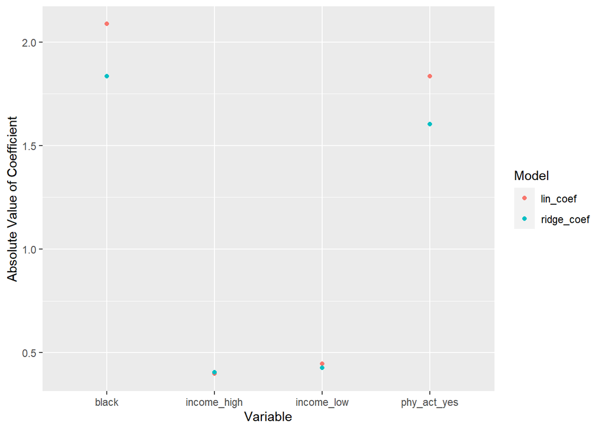

```r
b1_coef  %>%  merge(b2_coef, by="term") %>%
  dplyr::select(term, estimate.x, estimate.y) %>%
  rename(lin_coef= estimate.x, ridge_coef= estimate.y)%>%
  filter(term!= "(Intercept)") %>%
  pivot_longer(cols= -term, names_to= "Model", values_to= "Estimate") %>%
  ggplot()+
  geom_point(aes(term, abs(Estimate),color= Model))+
  labs(x= "Variable", y= "Absolute Value of Coefficient")
```